# Analyse du dataset Titanic

Ouissal CHEROUAT

2026-11-12

# Présentation des données :

Le jeu de données `TitanicSurvival` (package `carData`) contient des informations sur les passagers du Titanic, qui a fait naufrage en avril 1912. Chaque ligne correspond à un passager et les variables sont :

- `survived` : le passager a-t-il survécu ? (no / yes)
- `sex` : sexe du passager (female / male)
- `age` : âge en années (les enfants de moins d’un an ont un âge fractionnaire)
- `passengerClass` : classe du billet (1st, 2nd, 3rd)

```
## 'data.frame':    1309 obs. of  4 variables:
##  $ survived      : Factor w/ 2 levels "no","yes": 2 2 1 1 1 2 2 1 2 1 ...
##  $ sex           : Factor w/ 2 levels "female","male": 1 2 1 2 1 2 1 2 1 2 ...
##  $ age           : num  29 0.917 2 30 25 ...
##  $ passengerClass: Factor w/ 3 levels "1st","2nd","3rd": 1 1 1 1 1 1 1 1 1 1 ...
```

```
##  survived      sex           age          passengerClass
##  no :809   female:466   Min.   : 0.1667   1st:323
##  yes:500   male  :843   1st Qu.:21.0000   2nd:277
##                         Median :28.0000   3rd:709
##                         Mean   :29.8811
##                         3rd Qu.:39.0000
##                         Max.   :80.0000
##                         NAs    :263
```

# Présentation et statistiques descriptives :

Le jeu de données comprend 1 309 observations (passagers) réparties sur 4 variables. On dénombre 809 non-survivants pour 500 survivants. L’échantillon comporte 843 hommes et 466 femmes. Concernant la classe, la 3e classe est la plus représentée (709 passagers), suivie de la 1re classe (323) et de la 2e classe (277). L’âge moyen est d’environ 29,88 ans (médiane à 28 ans), avec un minimum de 0,17 an et un maximum de 80 ans, ainsi que 263 valeurs manquantes (NA).

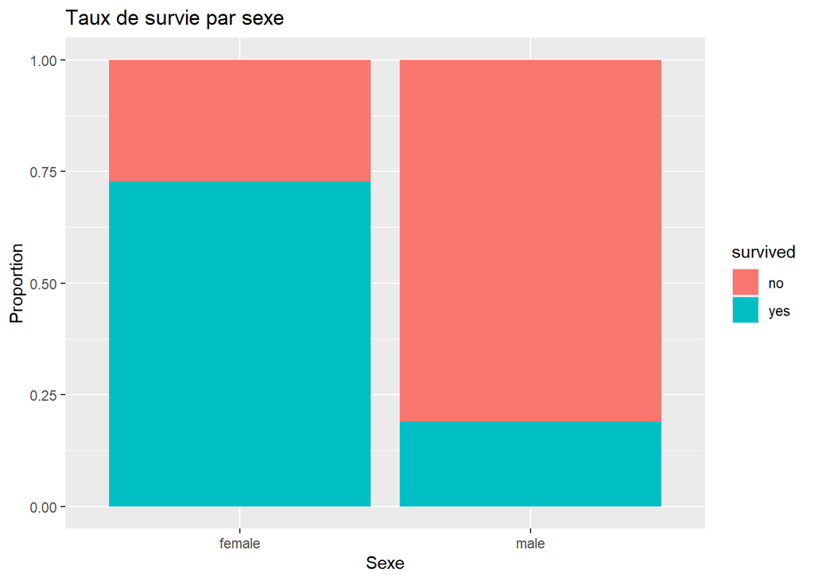

# Impact du Sexe :

Le taux de survie est radicalement plus élevé chez les femmes (~73 %) que chez les hommes (~19 %), illustrant la règle prioritaire d’évacuation (« les femmes et les enfants d’abord »).

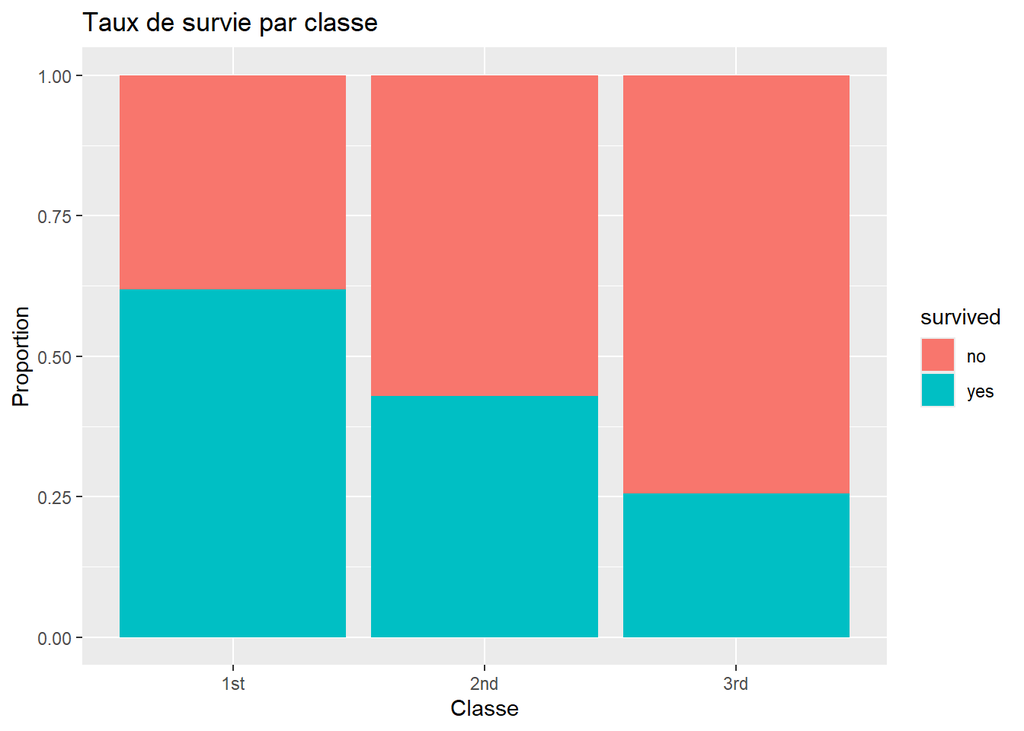

# Impact de la Classe :

La classe du billet a exercé un rôle majeur, le taux de survie chutant fortement selon le rang social, passant de ~62 % en 1ʳᵉ classe à ~43 % en 2ᵉ classe et ~26 % en 3ᵉ classe.

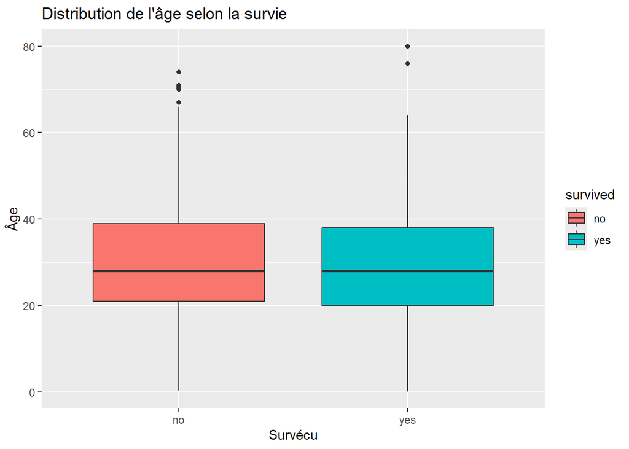

# Distribution de l’âge selon la survie :

Le diagramme en boîtes à moustaches montre que l’âge médian est très proche dans les deux groupes (environ 28 ans). La dispersion des âges (représentée par l’étendue des boîtes) et la présence de valeurs extrêmes chez les passagers plus âgés sont également similaires entre les survivants et les non-survivants. À première vue, l’âge ne semble donc pas être un facteur discriminant majeur dans la survie des passagers. Attention toutefois : 263 âges sont manquants, et ce graphique ne tient compte ni du sexe ni de la classe.

# Analyse avec le package personnalisé :

La fonction `taux_survie()` du package `TitanicPackage` calcule le taux de survie selon une variable donnée.

```r
# 1. Taux de survie en fonction du sexe
taux_survie(TitanicSurvival, "sex")
```

| sex | Effectif | TauxSurvie |
| --- | --- | --- |
| female | 466 | 0.7274678 |
| male | 843 | 0.1909846 |

```r
# 2. Taux de survie en fonction de la classe des passagers
taux_survie(TitanicSurvival, "passengerClass")
```

| passengerClass | Effectif | TauxSurvie |
| --- | --- | --- |
| 1st | 323 | 0.6191950 |
| 2nd | 277 | 0.4296029 |
| 3rd | 709 | 0.2552891 |

Les résultats obtenus avec le package sont les mêmes que ceux observés sur les graphiques : environ 73 % de survie chez les femmes contre 19 % chez les hommes, et 62 %, 43 % et 26 % de survie respectivement en 1re, 2e et 3e classe.

*Fin, Merci !*